# NBA Player of the Week Analysis

Greg Westfall

December 6, 2018

### In this project, we will be examining the different characteristics of NBA player of the week winners since 1985.

In order to look at these demographics, we first need to load the data table containing this information.

```r
library(DataComputing)
library(tidyverse)
library(readr)
# Read in the data
NBA_player_of_the_week <- read_csv("~/NBA_player_of_the_week.csv")
```

Next, we’ll take a look at what the table looks like.

```r
NBA_player_of_the_week <-
  NBA_player_of_the_week %>%
  filter(`Season short` < 2019) # We only want data before this season
head(NBA_player_of_the_week)
```

| Active season | Player | Team | Conference | Date | Position | Height | Weight | Age | Draft Year | Seasons in league | Season | Season short | Real_value |
| --- | --- | --- | --- | --- | --- | --- | --- | --- | --- | --- | --- | --- | --- |
| 0 | Micheal Ray Richardson | New Jersey Nets | NA | Apr 14, 1985 | PG | 6-5 | 189 | 29 | 1978 | 6 | 1984-1985 | 1985 | 1 |
| 0 | Derek Smith | Los Angeles Clippers | NA | Apr 7, 1985 | SG | 6-6 | 205 | 23 | 1982 | 2 | 1984-1985 | 1985 | 1 |
| 0 | Calvin Natt | Denver Nuggets | NA | Apr 1, 1985 | F | 6-6 | 220 | 28 | 1979 | 5 | 1984-1985 | 1985 | 1 |
| 0 | Kareem Abdul-Jabbar | Los Angeles Lakers | NA | Mar 24, 1985 | C | 7-2 | 225 | 37 | 1969 | 15 | 1984-1985 | 1985 | 1 |
| 0 | Larry Bird | Boston Celtics | NA | Mar 17, 1985 | SF | 6-9 | 220 | 28 | 1978 | 5 | 1984-1985 | 1985 | 1 |
| 0 | Darrell Griffith | Utah Jazz | NA | Mar 10, 1985 | SG | 6-4 | 190 | 26 | 1980 | 4 | 1984-1985 | 1985 | 1 |

## Players with the Most Awards

First, let’s look at which players have won the NBA player of the week award the most times since the 1984-85 season. LeBron James has been dominant in this award category, winning nearly twice as much as second place Kobe Bryant.

```r
NBA_player_of_the_week %>%
  group_by(Player) %>%
  summarise(count = n()) %>%
  arrange(desc(count)) %>%
  head(10)
```

| Player | count |
| --- | --- |
| LeBron James | 61 |
| Kobe Bryant | 33 |
| Kevin Durant | 26 |
| Michael Jordan | 25 |
| Allen Iverson | 23 |
| Karl Malone | 23 |
| Tim Duncan | 23 |
| Kevin Garnett | 20 |
| Shaquille O'Neal | 20 |
| Dwyane Wade | 19 |

## Adjusted Award Wins

However, up through the 2000-01 season, only one award was given every week for the whole league. Ever since the 2001-02 season, one award has been given each week for each conference, meaning that two players are named every week. Essentially, this makes POTW awards won since 2001 half as valuable. To account for this, we will multiply each player’s number of awards won since that time by 0.5.

We see that LeBron has still “won” the most times, but Michael Jordan and Karl Malone have closed the gap.

```r
NBA_player_of_the_week %>%
  group_by(Player, Real_value) %>%
  summarise(count = n()) %>%
  mutate(true_count = count * Real_value) %>%
  select(Player, true_count) %>%
  arrange(desc(true_count)) %>%
  head(10)
```

| Player | true_count |
| --- | --- |
| LeBron James | 30.5 |
| Michael Jordan | 23.0 |
| Karl Malone | 22.0 |
| Kobe Bryant | 15.5 |
| David Robinson | 15.0 |
| Kevin Durant | 13.0 |
| Hakeem Olajuwon | 12.0 |
| Magic Johnson | 12.0 |
| Patrick Ewing | 12.0 |
| Shaquille O'Neal | 12.0 |

## Ages of Winners

Next, we will look at the distribution of ages of all the Player of the Week winners. We can see that the most common age of winners is 25, followed by 28.

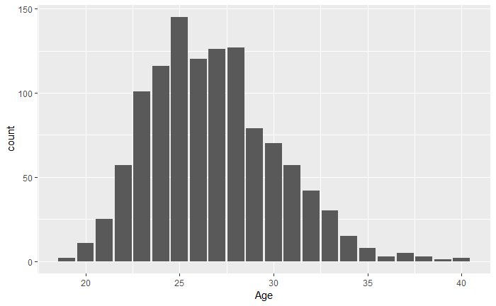

```r
NBA_player_of_the_week %>%
  group_by(Age) %>%
  summarise(count = n()) %>%
  ggplot(aes(x = Age, y = count)) +
  geom_bar(stat = "identity")
```

With all of the new technology we have to keep players healthy, it would be interesting to see if the average age of winners has increased over time. We will look at this next. When we view this, it’s hard to tell what’s going on due to the large amount of graphs.

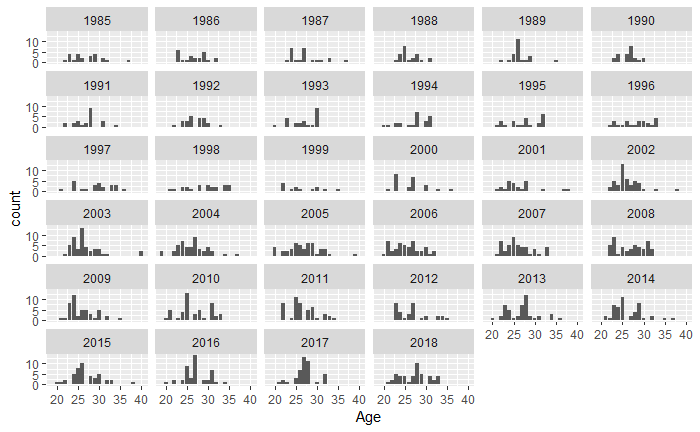

```r
NBA_player_of_the_week %>%
  group_by(Age, `Season short`) %>%
  summarise(count = n()) %>%
  ggplot(aes(x = Age, y = count)) +
  geom_bar(stat = "identity") +
  facet_wrap(~ `Season short`)
```

It will be easier to visualize the data if we calculate a variable containing the average age of winners for each year and then making a scatterplot out of this information.

When we do this, we see that there is really no relationship between year and age of winners.

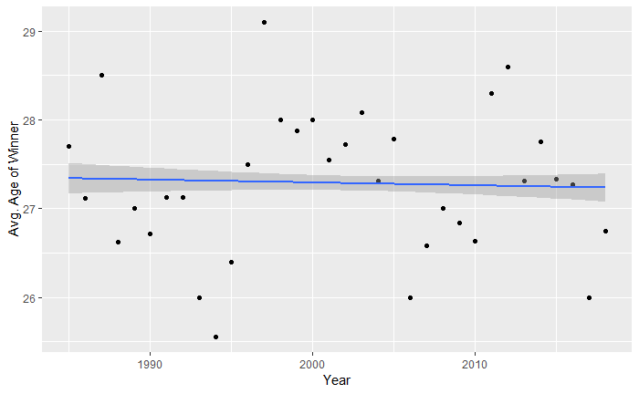

```r
NBA_ages <-
  NBA_player_of_the_week %>%
  group_by(`Season short`, Age) %>%
  summarise(count = n()) %>%
  mutate(average_age = mean(Age)) # Creates a variable containing average age of winners
NBA_ages %>%
  ggplot(aes(x = `Season short`, y = average_age)) +
  geom_point() +
  stat_smooth(method = lm) +
  xlab("Year") + ylab("Avg. Age of Winner")
```

However, in order to be sure, we’ll make a linear regression model of the data. As expected, the p-value of the slope of the regression line is 0.462, meaning that we can’t conclude that the slope is different than 0. Additionally, the r-squared value is 0.001, meaning that only 0.1% of the variation in age of winners is caused by the year.

```r
# Creates a linear regression model of the data
lmModAges <- lm(average_age ~ `Season short`, data = NBA_ages)
summary(lmModAges)
```

```
Call:
lm(formula = average_age ~ `Season short`, data = NBA_ages)

Residuals:
     Min       1Q   Median       3Q      Max
-1.75579 -0.48457  0.03176  0.50956  1.79825

Coefficients:
                Estimate Std. Error t value Pr(>|t|)
(Intercept)    33.690299   8.697651   3.873 0.000128 ***
`Season short` -0.003199   0.004343  -0.737 0.461888
---
Signif. codes:  0 ‘***’ 0.001 ‘**’ 0.01 ‘*’ 0.05 ‘.’ 0.1 ‘ ’ 1

Residual standard error: 0.7831 on 350 degrees of freedom
Multiple R-squared:  0.001548,  Adjusted R-squared:  -0.001305
F-statistic: 0.5425 on 1 and 350 DF,  p-value: 0.4619
```

## Heights of Winners

Next we will examine the distribution of heights of winners. This requires us to change the height from a character string to a numeric value. After doing this, we can see that most winners are at least 75 inches tall, or 6’3“.

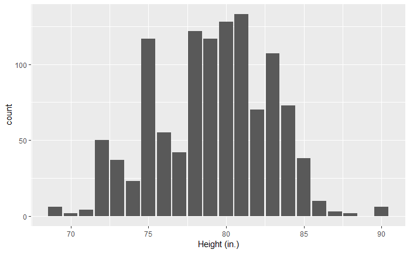

```r
# Function to convert height to inches (numeric) from a character string
NBA_player_of_the_week$Height_in <-
  sapply(strsplit(NBA_player_of_the_week$Height, "-"),
         function(x){12 * as.numeric(x[1]) + as.numeric(x[2])})
NBA_player_of_the_week %>%
  group_by(Height_in) %>%
  summarise(count = n()) %>%
  ggplot(aes(x = Height_in, y = count)) +
  geom_bar(stat = "identity") +
  xlab("Height (in.)")
```

Now we will examine the average height of winners over time (like we did with age) to see if basketball has evolved to favor taller or shorter players. Once again, it’s hard to tell what’s going on.

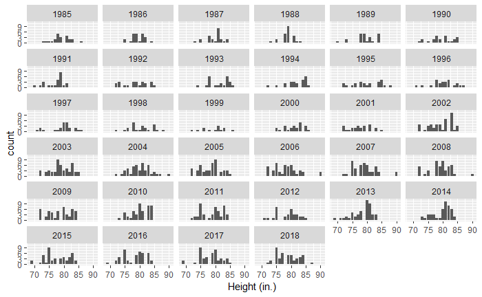

```r
NBA_player_of_the_week %>%
  group_by(Height_in, `Season short`) %>%
  summarise(count = n()) %>%
  ggplot(aes(x = Height_in, y = count)) +
  geom_bar(stat = "identity") +
  facet_wrap(~ `Season short`) +
  xlab("Height (in.)")
```

As we did before, it will be easier to make a scatterplot of the year and average height of winners. When we do this, it appears that the heights of winners might be getting shorter over time.

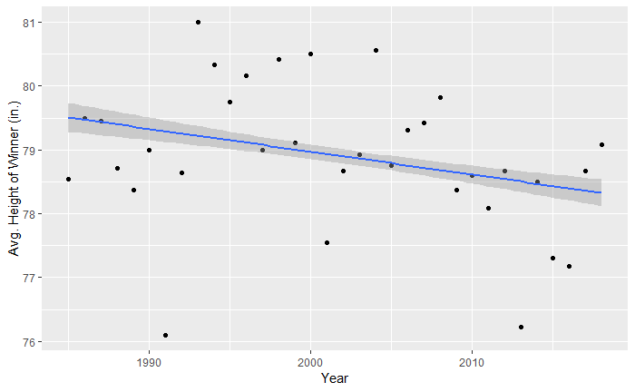

```r
NBA_height <-
  NBA_player_of_the_week %>%
  group_by(`Season short`, Height_in) %>%
  summarise(count = n()) %>%
  mutate(average_height = mean(Height_in)) # Creates a variable of average height by year
NBA_height %>%
  ggplot(aes(x = `Season short`, y = average_height)) +
  geom_point() +
  stat_smooth(method = lm) +
  xlab("Year") + ylab("Avg. Height of Winner (in.)")
```

To be sure that there is an association, we will once again create a linear regression model. From this, we can see that the p-value of the slope is virtually 0, meaning that the slope is definitely negative, or that the average height of winners is decreasing over time, albeit at 0.036 inches per year. Furthermore, the r-squared value is 0.09, meaning that 9% of the variability in height is due to the year.

```r
# Creates another linear regression model
lmModHeights <- lm(average_height ~ `Season short`, data = NBA_height)
summary(lmModHeights)
```

```
Call:
lm(formula = average_height ~ `Season short`, data = NBA_height)

Residuals:
    Min      1Q  Median      3Q     Max
-3.1932 -0.5576  0.0278  0.6960  1.7784

Coefficients:
                 Estimate Std. Error t value Pr(>|t|)
(Intercept)    150.543440  11.637757  12.936  < 2e-16 ***
`Season short`  -0.035786   0.005812  -6.157  1.9e-09 ***
---
Signif. codes:  0 ‘***’ 0.001 ‘**’ 0.01 ‘*’ 0.05 ‘.’ 0.1 ‘ ’ 1

Residual standard error: 1.083 on 377 degrees of freedom
Multiple R-squared:  0.09138,   Adjusted R-squared:  0.08897
F-statistic: 37.91 on 1 and 377 DF,  p-value: 1.896e-09
```

## Do Championship Teams Have Better Players?

It’s a well-known fact that you need a star player to win a championship, but are NBA teams that win it all more likely to have players win POTW throughout the season? We’ll examine this by first scraping a table of all the NBA champions from Basketball Reference.

```r
# Scraping the table from the Internet
library(rvest)
page <- "https://www.basketball-reference.com/playoffs/"
xpath <- '//*[@id="champions_index"]'
champions_table <- page %>%
  read_html() %>%
  html_nodes(xpath = xpath) %>%
  html_table(fill = TRUE)
champions <- champions_table[[1]]
# Setting the headers of the table manually
colnames(champions) <- as.character(champions[1,])
champions <-
  champions %>%
  filter(row_number() > 1)
champions
```

| Year | Lg | Champion | Runner-Up | Finals MVP | Points | Rebounds | Assists | Win Shares |
| --- | --- | --- | --- | --- | --- | --- | --- | --- |
| 2018 | NBA | Golden State Warriors | Cleveland Cavaliers | K. Durant | L. James (748) | D. Green (222) | L. James (198) | L. James (5.2) |
| 2017 | NBA | Golden State Warriors | Cleveland Cavaliers | K. Durant | L. James (591) | K. Love (191) | L. James (141) | L. James (4.3) |
| 2016 | NBA | Cleveland Cavaliers | Golden State Warriors | L. James | K. Thompson (582) | D. Green (228) | R. Westbrook (198) | L. James (4.7) |
| 2015 | NBA | Golden State Warriors | Cleveland Cavaliers | A. Iguodala | L. James (601) | D. Howard (238) | L. James (169) | S. Curry (3.9) |
| 2014 | NBA | San Antonio Spurs | Miami Heat | K. Leonard | K. Durant (563) | T. Duncan (211) | R. Westbrook (153) | L. James (4.3) |
| 2013 | NBA | Miami Heat | San Antonio Spurs | L. James | L. James (596) | T. Duncan (214) | L. James (152) | L. James (5.2) |
| 2012 | NBA | Miami Heat | Oklahoma City Thunder | L. James | L. James (697) | L. James (224) | R. Rondo (227) | L. James (5.8) |
| 2011 | NBA | Dallas Mavericks | Miami Heat | D. Nowitzki | D. Nowitzki (582) | T. Chandler (193) | J. Kidd (153) | L. James (3.8) |
| 2010 | NBA | Los Angeles Lakers | Boston Celtics | K. Bryant | K. Bryant (671) | P. Gasol (255) | R. Rondo (223) | P. Gasol (4.3) |
| 2009 | NBA | Los Angeles Lakers | Orlando Magic | K. Bryant | K. Bryant (695) | D. Howard (353) | R. Rondo (137) | L. James (4.8) |

[output cut: 75 more lines]

Next, we’ll change the year to a numeric value and whittle the table down to all we really care about.

```r
champions <-
  champions %>%
  mutate(Year = as.numeric(Year)) %>%
  select(Year, Champion)
champions
```

| Year | Champion |
| --- | --- |
| 2018 | Golden State Warriors |
| 2017 | Golden State Warriors |
| 2016 | Cleveland Cavaliers |
| 2015 | Golden State Warriors |
| 2014 | San Antonio Spurs |
| 2013 | Miami Heat |
| 2012 | Miami Heat |
| 2011 | Dallas Mavericks |
| 2010 | Los Angeles Lakers |
| 2009 | Los Angeles Lakers |

[output cut: 75 more lines]

Then, we will join this table to our POTW table and set up a way to check if a player’s team won the championship that season.

```r
NBA_player_of_the_week <-
  NBA_player_of_the_week %>%
  left_join(champions, by = c("Season short" = "Year"))
```

```r
# Checks for equality between a POTW's team and the champion that year
NBA_player_of_the_week <-
  NBA_player_of_the_week %>%
  mutate(champ = (Team == Champion))
NBA_player_of_the_week %>%
  select(Player, `Season short`, Team, champ)
```

| Player | Season short | Team | champ |
| --- | --- | --- | --- |
| Micheal Ray Richardson | 1985 | New Jersey Nets | FALSE |
| Derek Smith | 1985 | Los Angeles Clippers | FALSE |
| Calvin Natt | 1985 | Denver Nuggets | FALSE |
| Kareem Abdul-Jabbar | 1985 | Los Angeles Lakers | TRUE |
| Larry Bird | 1985 | Boston Celtics | FALSE |
| Darrell Griffith | 1985 | Utah Jazz | FALSE |
| Sleepy Floyd | 1985 | Golden State Warriors | FALSE |
| Mark Aguirre | 1985 | Dallas Mavericks | FALSE |
| Magic Johnson | 1985 | Los Angeles Lakers | TRUE |
| Dominique Wilkins | 1985 | Atlanta Hawks | FALSE |

[output cut: 990 more lines]

```r
NA
```

Next we need to check to see if the proportion of winners on championship teams is different from the expected value. Since the number of NBA teams has grown over time, we will need to add a new variable to the table containing the number of teams in the league at that time.

```r
# Adds a different number of teams based on what year it is
NBA_player_of_the_week <-
  NBA_player_of_the_week %>%
  mutate(num_teams = case_when(`Season short` > 1984 & `Season short` < 1989 ~ 23,
                               `Season short` == 1989 ~ 25,
                               `Season short` > 1989 & `Season short` < 1996 ~ 27,
                               `Season short` > 1995 & `Season short` < 2005 ~ 29,
                               `Season short` > 2004 ~ 30))
NBA_player_of_the_week %>%
  select(Player, `Season short`, Team, champ, num_teams)
```

| Player | Season short | Team | champ | num_teams |
| --- | --- | --- | --- | --- |
| Micheal Ray Richardson | 1985 | New Jersey Nets | FALSE | 23 |
| Derek Smith | 1985 | Los Angeles Clippers | FALSE | 23 |
| Calvin Natt | 1985 | Denver Nuggets | FALSE | 23 |
| Kareem Abdul-Jabbar | 1985 | Los Angeles Lakers | TRUE | 23 |
| Larry Bird | 1985 | Boston Celtics | FALSE | 23 |
| Darrell Griffith | 1985 | Utah Jazz | FALSE | 23 |
| Sleepy Floyd | 1985 | Golden State Warriors | FALSE | 23 |
| Mark Aguirre | 1985 | Dallas Mavericks | FALSE | 23 |
| Magic Johnson | 1985 | Los Angeles Lakers | TRUE | 23 |
| Dominique Wilkins | 1985 | Atlanta Hawks | FALSE | 23 |

[output cut: 990 more lines]

Next, we need to see what proportion of POTW winners’ teams won the championship later that season. This number turns out to be around 0.09.

```r
ChampWins <-
  NBA_player_of_the_week %>%
  filter(champ == TRUE) # Only keeps players who won the championship that year
prct_champ <- nrow(ChampWins) / nrow(NBA_player_of_the_week)
prct_champ
```

```
[1] 0.09170306
```

Now, we need to calculate the average chance of a championship team having a player win player of the week. This number equates to 0.035, which is much less than the observed value.

```r
ProbOfChampWinning <-
NBA_player_of_the_week %>%
  mutate(prob_winning = 1 / num_teams) %>%
  mutate(avg_prob = sum(prob_winning) / nrow(NBA_player_of_the_week))
avg_prob <- ProbOfChampWinning[1, "avg_prob"]
avg_prob
```

| avg_prob |
| --- |
| 0.03499781 |

To see if this is significantly different from the expected value, we’ll run a hypothesis test. The p-value turns out to be 0, which means that players from championship teams are (somewhat unsurprisingly) more likely to win the award.

```r
prop.test(105, 1145, p = 0.03499781,
          alternative = "greater",
          conf.level = 0.95, correct = TRUE)
```

```
    1-sample proportions test with continuity correction

data:  105 out of 1145, null probability 0.03499781
X-squared = 107.34, df = 1, p-value < 2.2e-16
alternative hypothesis: true p is greater than 0.03499781
95 percent confidence interval:
 0.07821422 1.00000000
sample estimates:
         p
0.09170306
```

## Does Last Name Matter?

As strange as it may sound, it’s been said that people with last names starting near the top of the alphabet are more likely to be successful in life. We’ll investigate that by seeing if players with last names starting with A, B, or C have a higher chance the award than other players. According to *Answers.com*, the proportion of Americans having last names that start with A, B, and C are 0.0375, 0.0896, and 0.0638, respectively.

When added up, we expect 0.1909 of the winners to have last names starting with these 3 letters.

```r
A <- 0.0375
B <- 0.0896
C <- 0.0638
expected_prop <- A + B + C
expected_prop
```

```
[1] 0.1909
```

Now we’ll see what proportion of award winners have last names near the top of the alphabet.

```r
ABCwinners <-
  NBA_player_of_the_week %>%
  filter(grepl(" A| B| C", Player)) # Filters out those who don't have A, B, or C surnames
ABCwinners %>%
  select(Player, Team, `Season short`)
```

| Player | Team | Season short |
| --- | --- | --- |
| Kareem Abdul-Jabbar | Los Angeles Lakers | 1985 |
| Larry Bird | Boston Celtics | 1985 |
| Mark Aguirre | Dallas Mavericks | 1985 |
| World B. Free | Cleveland Cavaliers | 1985 |
| Terry Cummings | Milwaukee Bucks | 1985 |
| Charles Barkley | Philadelphia Sixers | 1986 |
| Larry Bird | Boston Celtics | 1986 |
| Charles Barkley | Philadelphia Sixers | 1986 |
| Larry Bird | Boston Celtics | 1986 |
| Charles Barkley | Philadelphia Sixers | 1986 |

[output cut: 187 more lines]

When we calculate the true proportion, it turns out to be lower than our expected value.

```r
prop_ABC <- nrow(ABCwinners) / nrow(NBA_player_of_the_week)
prop_ABC
```

```
[1] 0.1720524
```

Nevertheless, we’ll still run a hypothesis test to see if the proportion is significantly different. When we do this, we get a p-value of 0.11, meaning that we can say that there is no difference (positive or negative) between the proportion of players with surnames at the top of the alphabet winning the award compared to other players.

```r
prop.test(197, 1145, p = 0.1909,
          alternative = "two.sided",
          conf.level = 0.95, correct = TRUE)
```

```
    1-sample proportions test with continuity correction

data:  197 out of 1145, null probability 0.1909
X-squared = 2.5127, df = 1, p-value = 0.1129
alternative hypothesis: true p is not equal to 0.1909
95 percent confidence interval:
 0.1508833 0.1954583
sample estimates:
        p
0.1720524
```

## Conclusion

Well, we certainly found some interesting aspects of the NBA Player of the Week data set, most notably the declining height of winners, the continued greatness of players from championship teams, and the dominance of LeBron James.

I hope you all learned something from this study, I know I sure did!